# COVID-19 Epidemic Information

Nick Lauerman

# Set up

## R Libraries

R is extended using packages or libraries. For this analysis the following packages are used.

```r
library(tidyverse)
library(lubridate)
```

Note: the tidyverse package loads a set of packages that make up the tidy data universe. Use of the tidyverse package to load these packages is a convince instead of loading each individual backage.

## Get data

Two R scripts are used to read in the data used. The source of this data is the WHO, for world wide data, and the CDC for US data. While the WHO data contains data for the US the CDC data is being used. The WHO data is a series of files scraped from their daily situtation reports and the CDC data is scraped from their web site for the CORANA virus. Due tothe WHO data being in 85 plus files the execution of these scripts is not shown to insure that the files is not overly large.

## Create data set for Germany

The data for Germany is extracted from the WHO data for easy in displaying

```r
germany <- WHO %>%
     filter(`Country Territory area` == "Germany")
```

## Create data set for world wide data

This data set displays the daily total for world wide data.

```r
world <- WHO %>%
     group_by(`date`) %>%
     summarise(`Number of new cases` = sum(`Confirmed new cases`),
               cum = sum(`total Confirmed Cases`))
world$`Week Number` <- week(world$date)
```

# Charts and graphs

## World Wide

```r
epi <- ggplot(data = world)
```

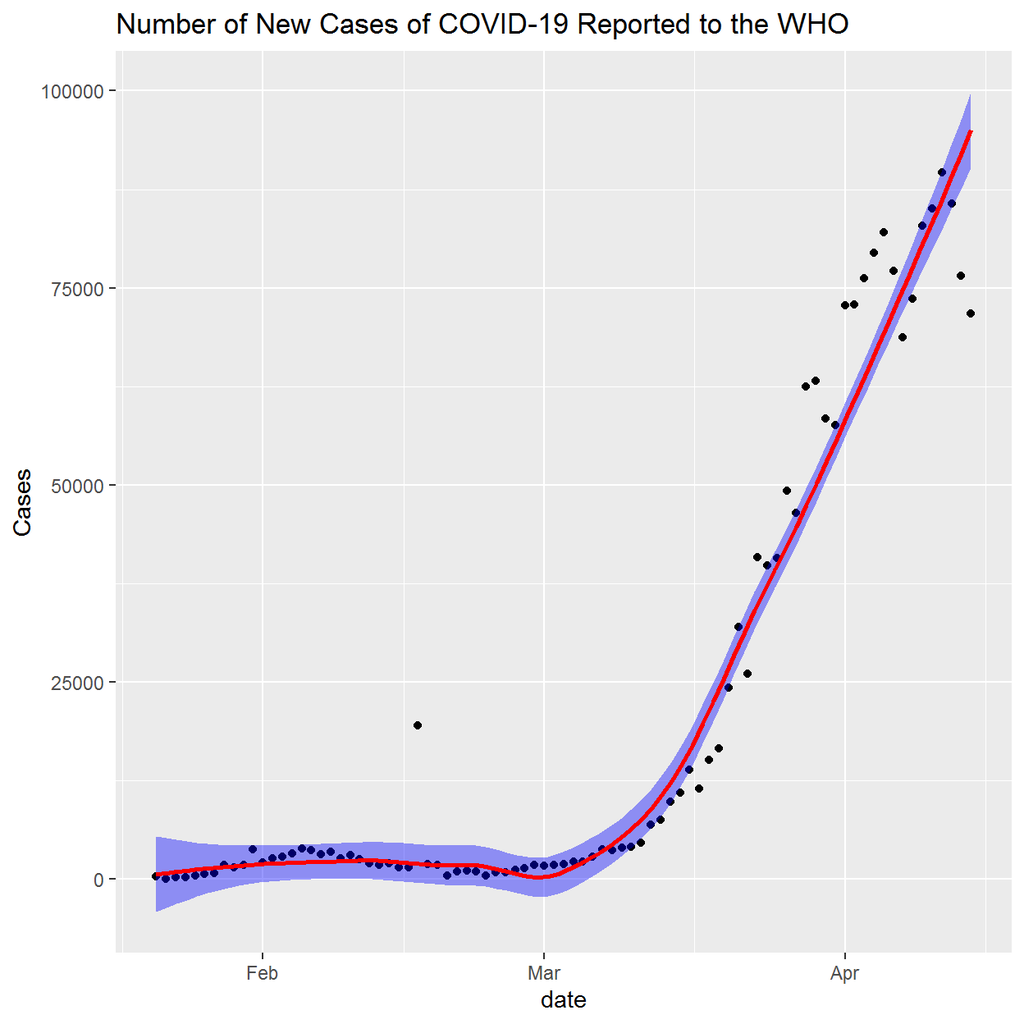

Epi curve 1

```r
epi + geom_point(aes(x = date,
              y = `Number of new cases`))+
     geom_smooth(aes(x = date,
              y = `Number of new cases`),
              color = "red",
              fill = "blue") +
     labs(y = "Cases",
          title = "Number of New Cases of COVID-19 Reported to the WHO")
```

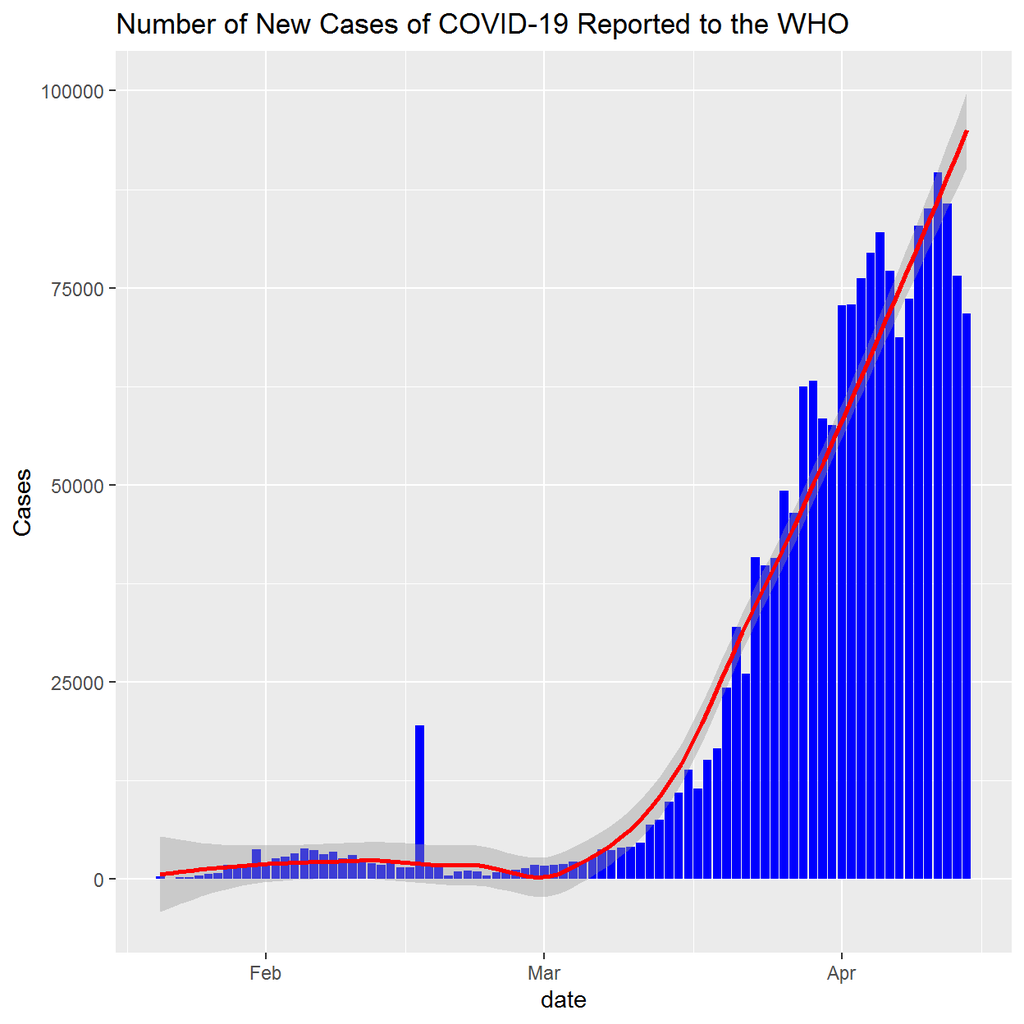

Epi curve 2, traditional

```r
epi + geom_col(aes(x=date,
                   y=`Number of new cases`),
               fill= "blue") +
     geom_smooth(aes(x=date,
                   y=`Number of new cases`),
                 color = "red") +
     labs(y = "Cases",
          title = "Number of New Cases of COVID-19 Reported to the WHO")
```

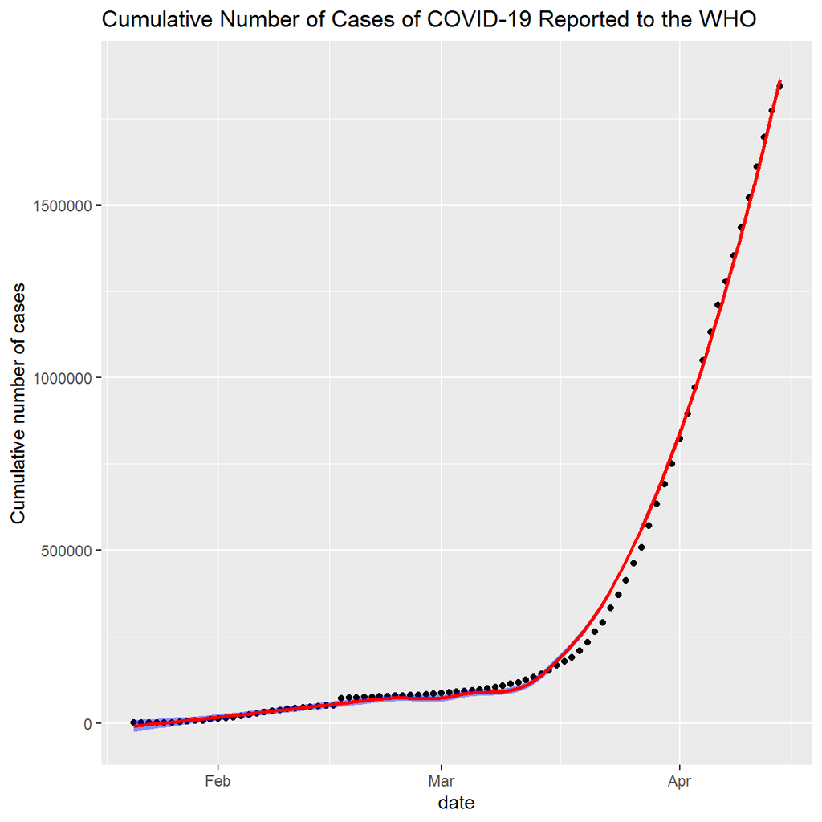

Cumulative cases

```r
epi + geom_point(aes(x = date,
              y = cum))+
     geom_smooth(aes(x = date,
              y = `cum`),
              color = "red",
              fill = "blue") +
     labs(y = "Cumulative number of cases",
          title = "Cumulative Number of Cases of COVID-19 Reported to the WHO")
```

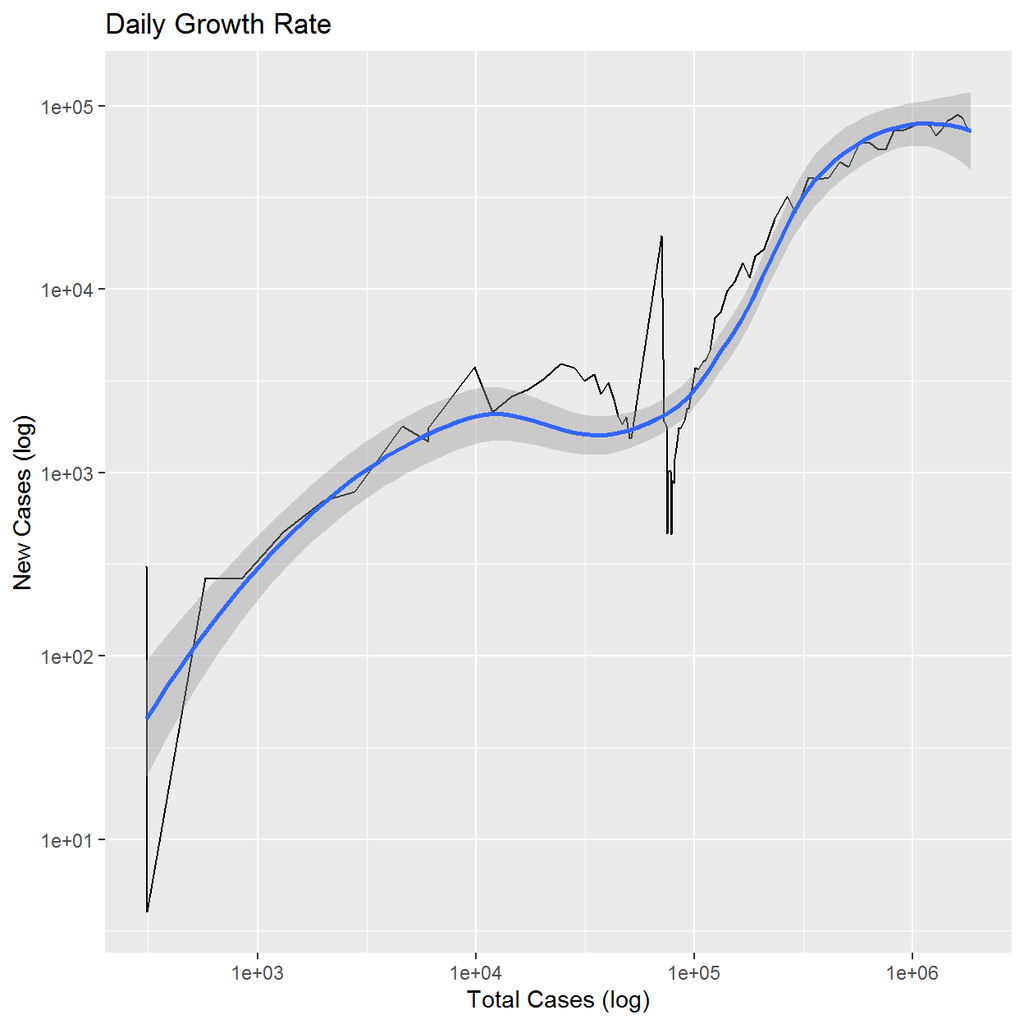

Growth Rate

```r
gr <- world %>%
  filter(`Number of new cases` != 0)

ggplot(data = gr) +
  geom_line(aes(y = `Number of new cases`,
                    x = cum)) +
  scale_x_log10() +
  scale_y_log10() +
  geom_smooth(aes(y = `Number of new cases`,
                    x = cum)) +
  labs(title = "Daily Growth Rate",
       x = "Total Cases (log)",
       y = "New Cases (log)")
```

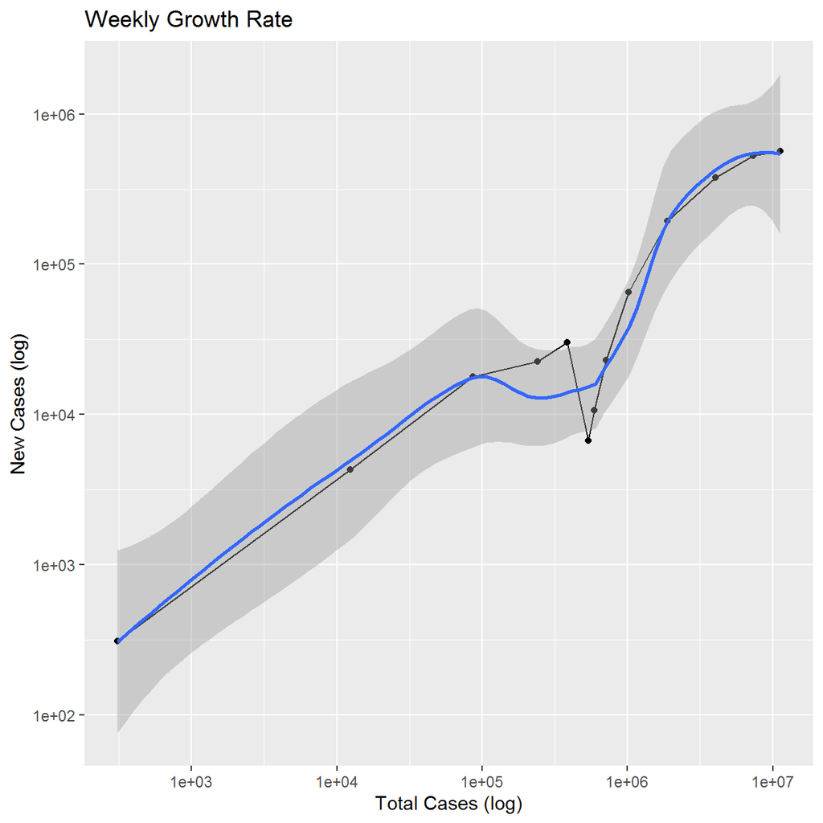

weekly growth rate

```r
gr <- world %>%
     group_by(`Week Number`) %>%
     summarise(cases = sum(`Number of new cases`),
               cs = sum(cum),
               count = n())

ggplot(data = gr) +
     geom_line(aes(y = `cases`,
                   x = cs)) +
     geom_point(aes(y = `cases`,
                    x = cs)) +
     scale_x_log10() +
     scale_y_log10() +
     geom_smooth(aes(y = `cases`,
                     x = cs)) +
  labs(title = "Weekly Growth Rate",
       x = "Total Cases (log)",
       y = "New Cases (log)")
```

## Germany

```r
epi <- ggplot(data = germany)
```

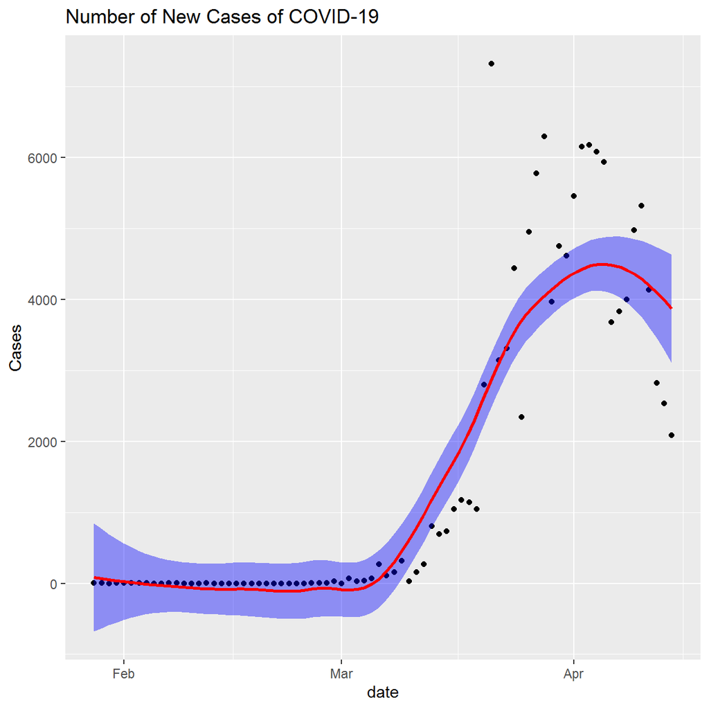

Epi curve 1

```r
epi + geom_point(aes(x = date,
              y = `Confirmed new cases`))+
     geom_smooth(aes(x = date,
              y = `Confirmed new cases`),
              color = "red",
              fill = "blue") +
     labs(y = "Cases",
          title = "Number of New Cases of COVID-19")
```

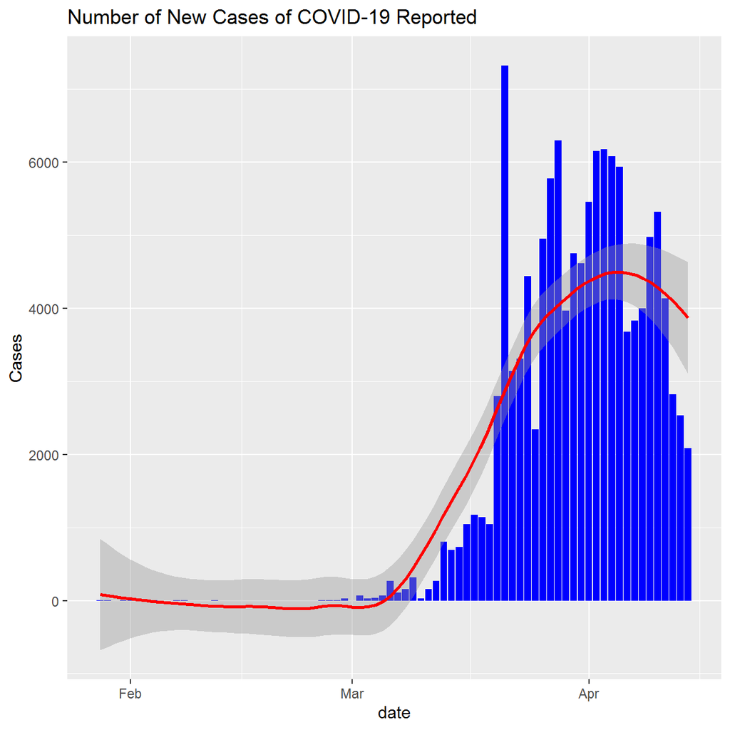

Epi curve 2, traditional

```r
epi + geom_col(aes(x=date,
                   y=`Confirmed new cases`),
               fill= "blue") +
     geom_smooth(aes(x=date,
                   y=`Confirmed new cases`),
                 color = "red") +
     labs(y = "Cases",
          title = "Number of New Cases of COVID-19 Reported")
```

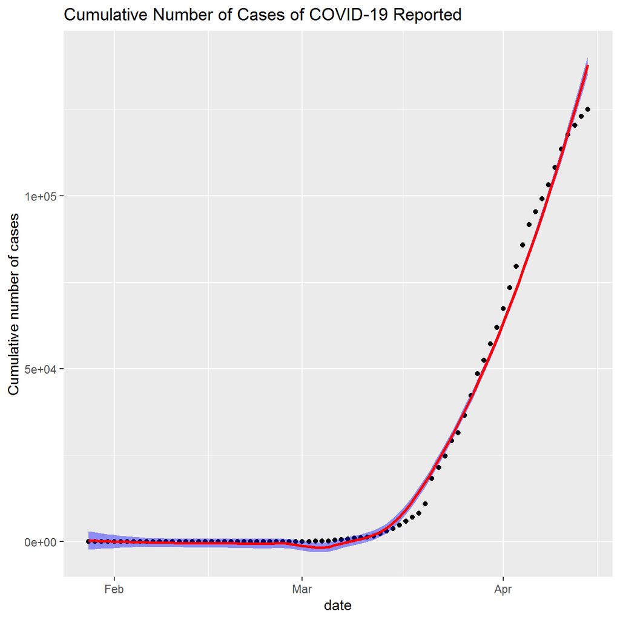

Cumulative cases

```r
epi + geom_point(aes(x = date,
              y = `total Confirmed Cases`))+
     geom_smooth(aes(x = date,
              y = `total Confirmed Cases`),
              color = "red",
              fill = "blue") +
     labs(y = "Cumulative number of cases",
          title = "Cumulative Number of Cases of COVID-19 Reported")
```

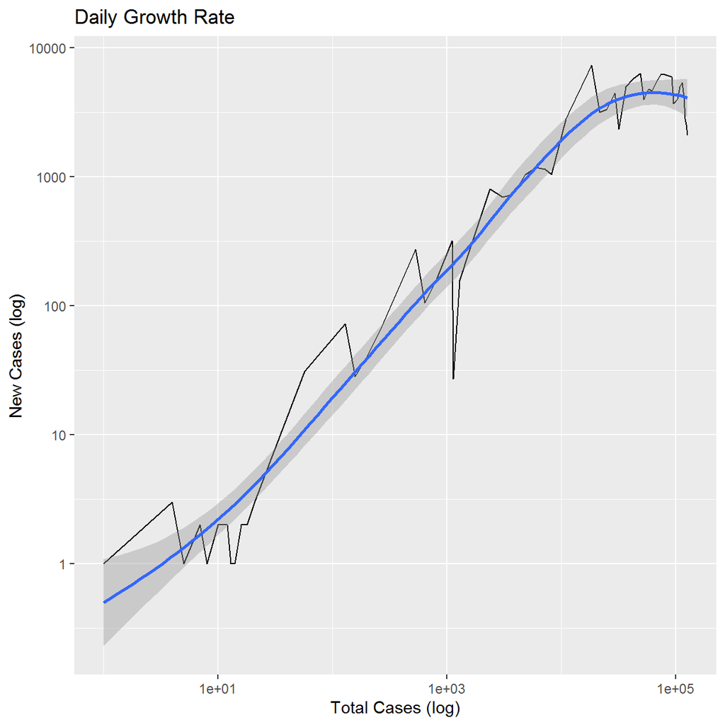

Growth Rate

```r
gr <- germany %>%
  filter(`Confirmed new cases` != 0)

ggplot(data = gr) +
  geom_line(aes(y = `Confirmed new cases`,
                    x = `total Confirmed Cases`)) +
  scale_x_log10() +
  scale_y_log10() +
  geom_smooth(aes(y = `Confirmed new cases`,
                    x = `total Confirmed Cases`)) +
  labs(title = "Daily Growth Rate",
       x = "Total Cases (log)",
       y = "New Cases (log)")
```

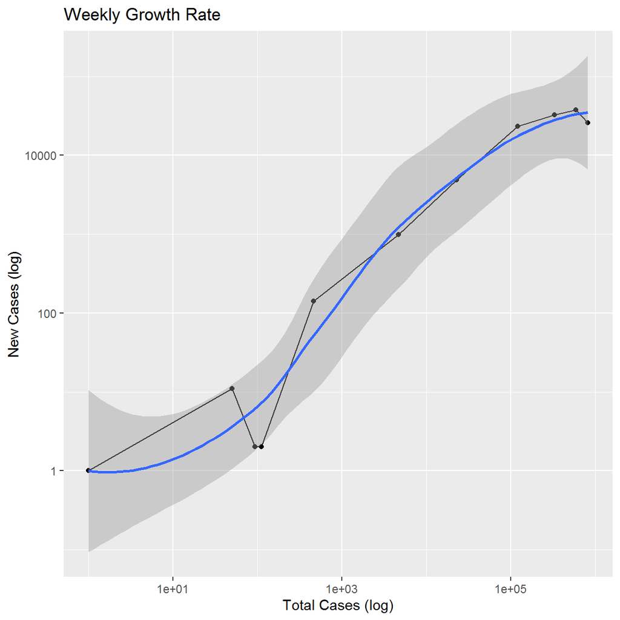

```r
gr <- germany %>%
     group_by(`Week Number`) %>%
     summarise(cases = sum(`Confirmed new cases`),
               cs = sum(`total Confirmed Cases`),
               count = n()) %>%
     filter(cases != 0)

ggplot(data = gr) +
     geom_line(aes(y = `cases`,
                   x = cs)) +
     geom_point(aes(y = `cases`,
                    x = cs)) +
     scale_x_log10() +
     scale_y_log10() +
     geom_smooth(aes(y = `cases`,
                     x = cs)) +
  labs(title = "Weekly Growth Rate",
       x = "Total Cases (log)",
       y = "New Cases (log)")
```

## US

### Complete data set

CDC designates a date to which they consider the data “good”. Reported data after that date is considered incomplete due to delays in reporting. This intial set of plots uses the complete data set

```r
epi <- ggplot(data = cdc)
```

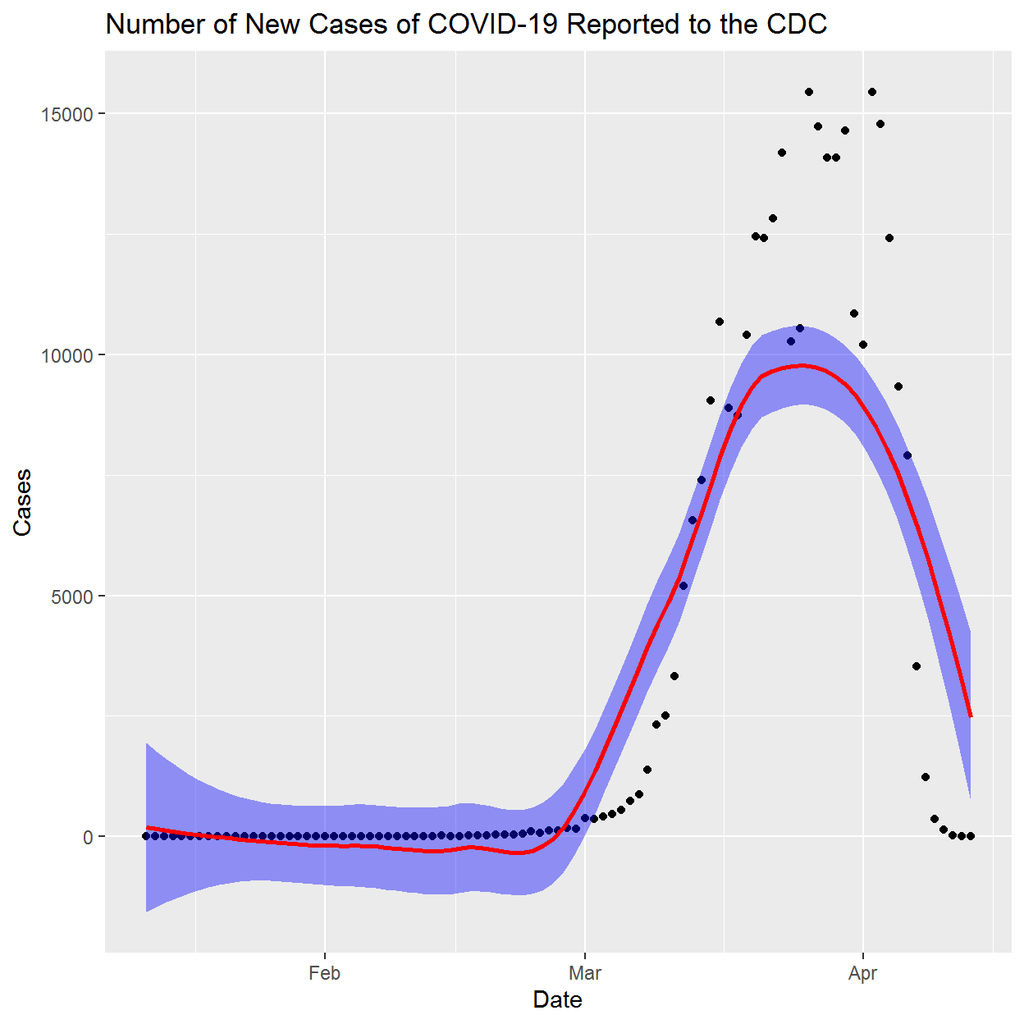

Epi curve 1

```r
epi + geom_point(aes(x = Date,
              y = `Number of new cases`))+
     geom_smooth(aes(x = Date,
              y = `Number of new cases`),
              color = "red",
              fill = "blue") +
     labs(y = "Cases",
          title = "Number of New Cases of COVID-19 Reported to the CDC")
```

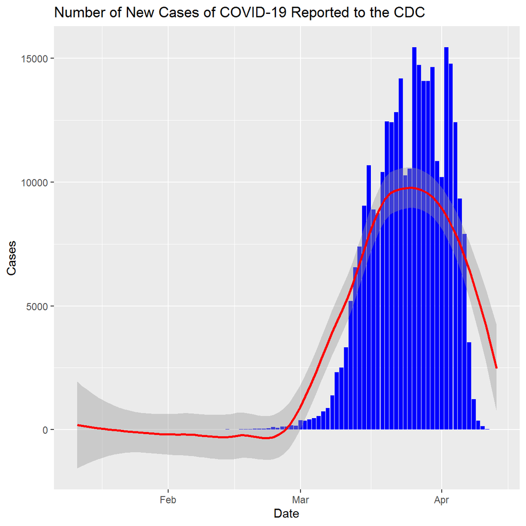

Epi curve 2, traditional

```r
epi + geom_col(aes(x=Date,
                   y=`Number of new cases`),
               fill= "blue") +
     geom_smooth(aes(x=Date,
                   y=`Number of new cases`),
                 color = "red") +
     labs(y = "Cases",
          title = "Number of New Cases of COVID-19 Reported to the CDC")
```

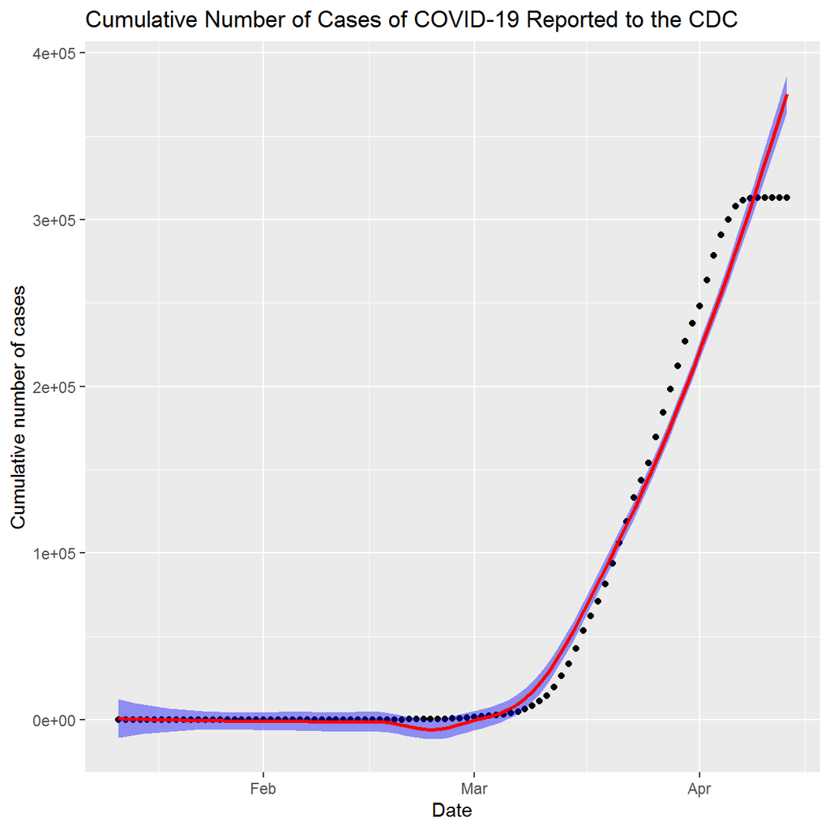

Cumulative cases

```r
epi + geom_point(aes(x = Date,
              y = cum))+
    # geom_line(aes(x = Date,
              #y = `cum`)) +
     geom_smooth(aes(x = Date,
              y = `cum`),
              color = "red",
              fill = "blue") +
     labs(y = "Cumulative number of cases",
          title = "Cumulative Number of Cases of COVID-19 Reported to the CDC")
```

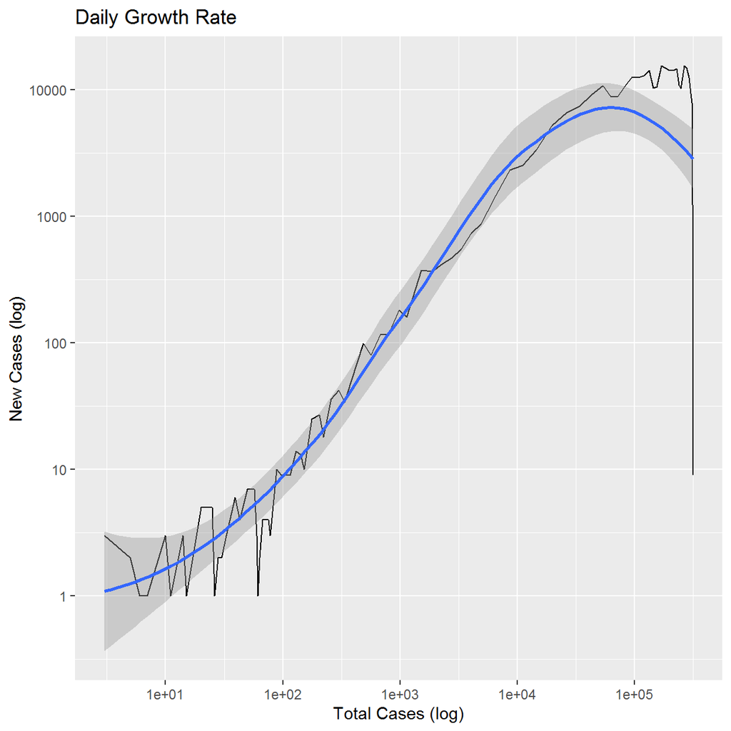

Growth Rate

```r
gr <- cdc %>%
  filter(`Number of new cases` != 0)

ggplot(data = gr) +
  geom_line(aes(y = `Number of new cases`,
                    x = cum)) +
  scale_x_log10() +
  scale_y_log10() +
  geom_smooth(aes(y = `Number of new cases`,
                    x = cum)) +
  labs(title = "Daily Growth Rate",
       x = "Total Cases (log)",
       y = "New Cases (log)")
```

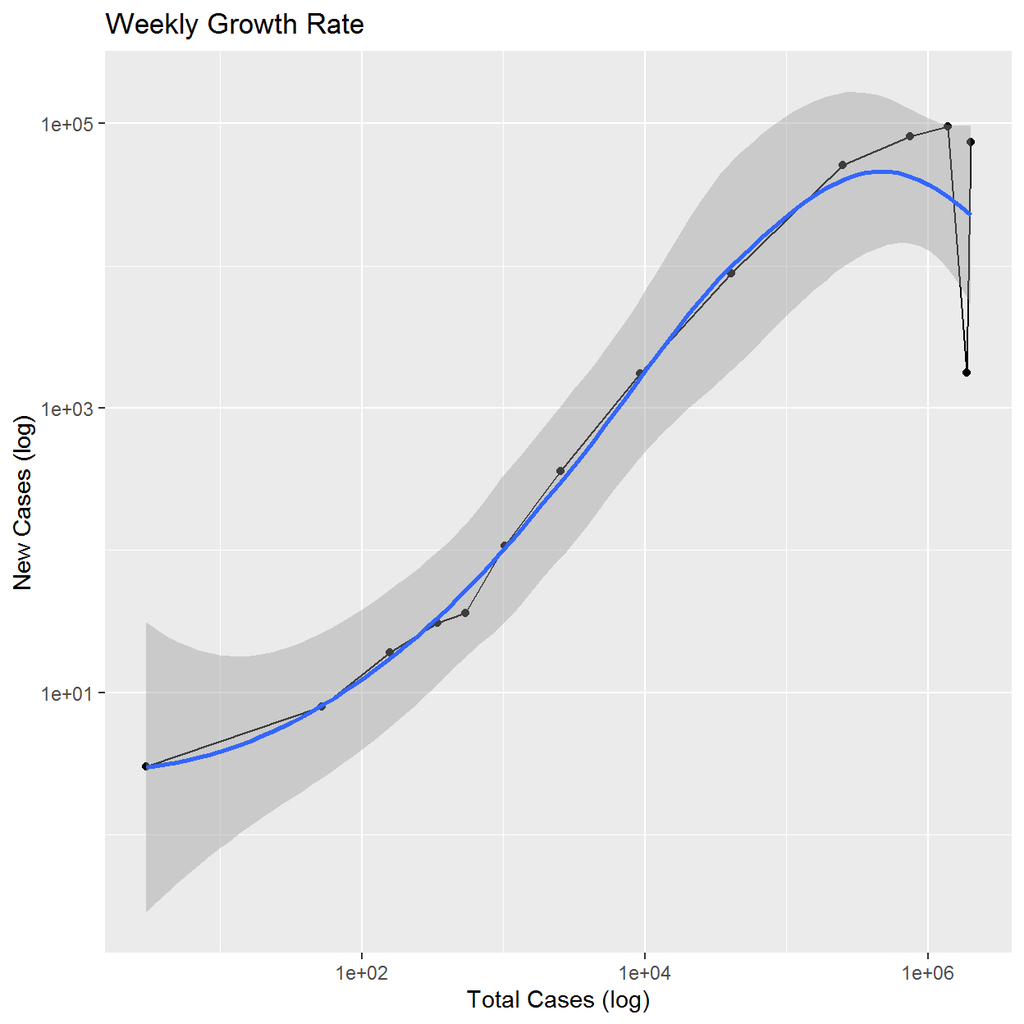

weekly growth rate

```r
gr <- cdc %>%
     group_by(`Week Number`) %>%
     summarise(cases = sum(`Number of new cases`),
               cs = sum(cum),
               count = n())

ggplot(data = gr) +
     geom_line(aes(y = `cases`,
                   x = cs)) +
     geom_point(aes(y = `cases`,
                    x = cs)) +
     scale_x_log10() +
     scale_y_log10() +
     geom_smooth(aes(y = `cases`,
                     x = cs)) +
  labs(title = "Weekly Growth Rate",
       x = "Total Cases (log)",
       y = "New Cases (log)")
```

### Filtered to use only complete data

Remove dates on or after 3 April as this data may not be completely reported

```r
cdc <- cdc %>%                                                                          # update with good date
     filter(Date < as.Date("2020-04-03")) %>%
  filter(`Number of new cases` != 0)
```

```r
epi <- ggplot(data = cdc)
```

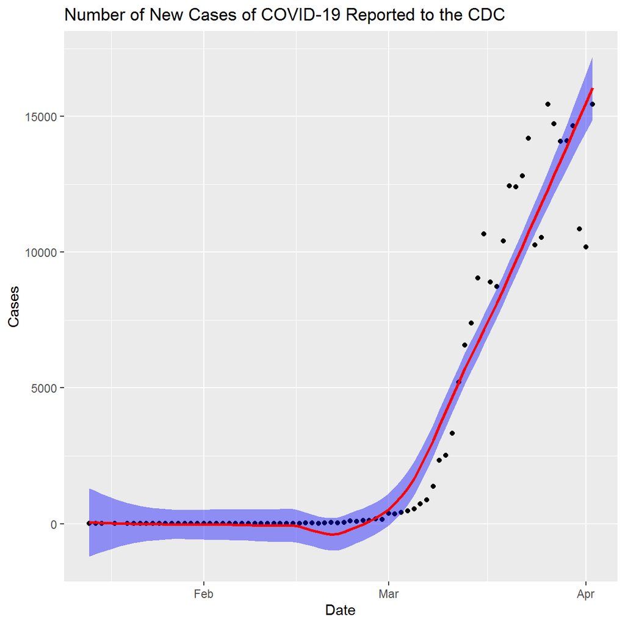

stable Epi curve

```r
epi + geom_point(aes(x = Date,
              y = `Number of new cases`))+
     geom_smooth(aes(x = Date,
              y = `Number of new cases`),
              color = "red",
              fill = "blue") +
     labs(y = "Cases",
          title = "Number of New Cases of COVID-19 Reported to the CDC")
```

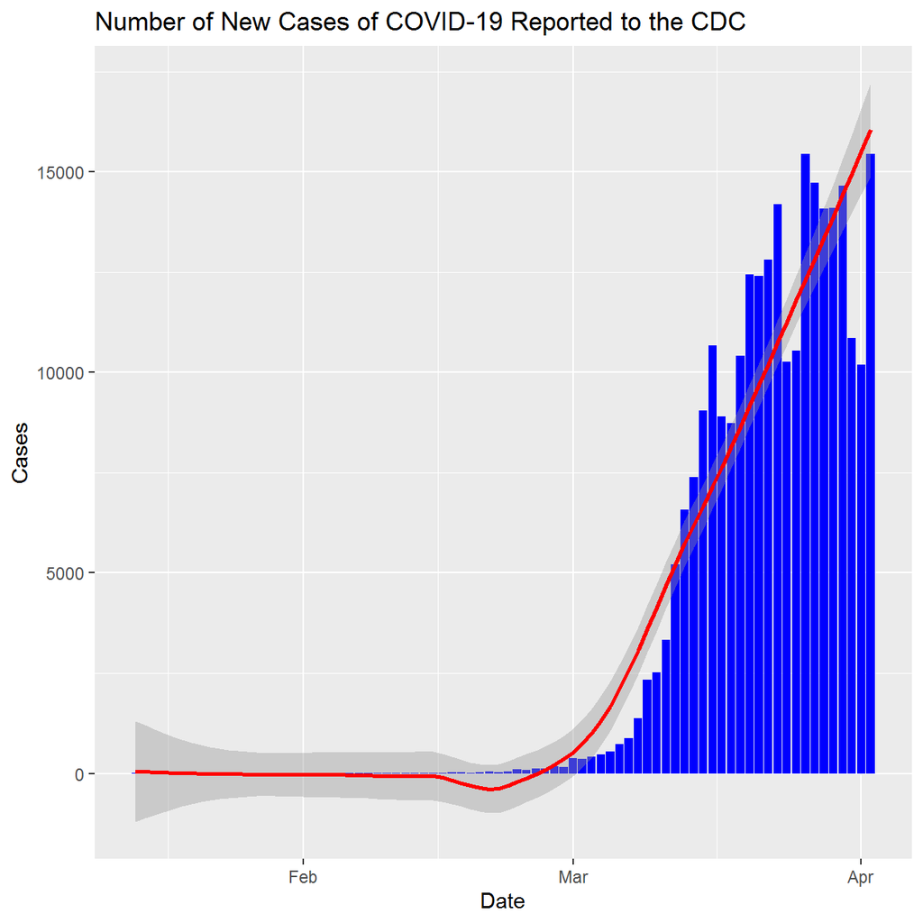

stable Epi curve, traditional

```r
epi + geom_col(aes(x=Date,
                   y=`Number of new cases`),
               fill= "blue") +
     geom_smooth(aes(x=Date,
                   y=`Number of new cases`),
                 color = "red") +
     labs(y = "Cases",
          title = "Number of New Cases of COVID-19 Reported to the CDC")
```

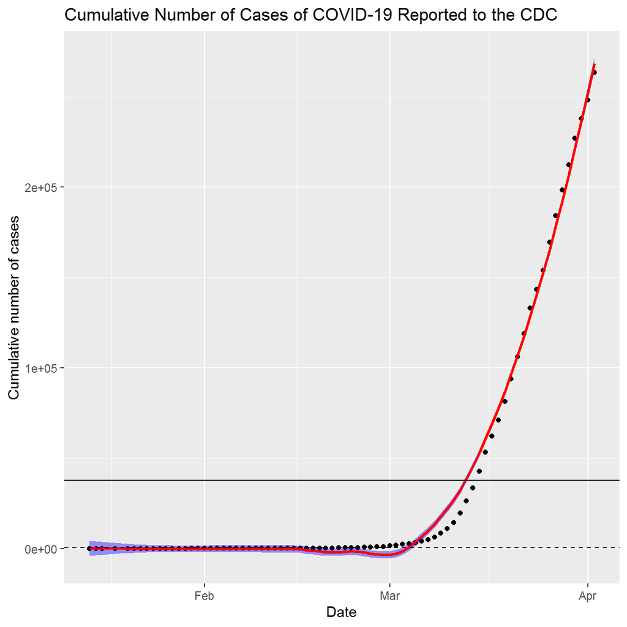

stable Cumulative cases

```r
epi + geom_point(aes(x = Date,
                     y = cum))+
  geom_smooth(aes(x = Date,
                  y = `cum`),
              color = "red",
              fill = "blue") +
  labs(y = "Cumulative number of cases",
       title = "Cumulative Number of Cases of COVID-19 Reported to the CDC") +
  geom_hline(yintercept = mean(cdc$cum)) +
  geom_hline(yintercept = median(cdc$cum),
             lty = 2)
```

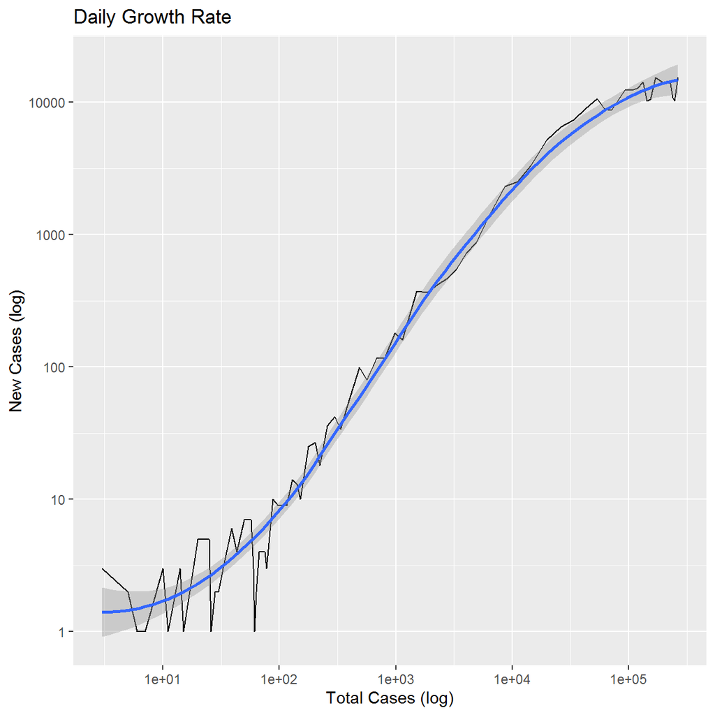

stable Growth Rate

```r
gr <- cdc %>%
  filter(`Number of new cases` != 0)

ggplot(data = gr) +
  geom_line(aes(y = `Number of new cases`,
                    x = cum)) +
  scale_x_log10() +
  scale_y_log10() +
  geom_smooth(aes(y = `Number of new cases`,
                    x = cum)) +
  labs(title = "Daily Growth Rate",
       x = "Total Cases (log)",
       y = "New Cases (log)")
```

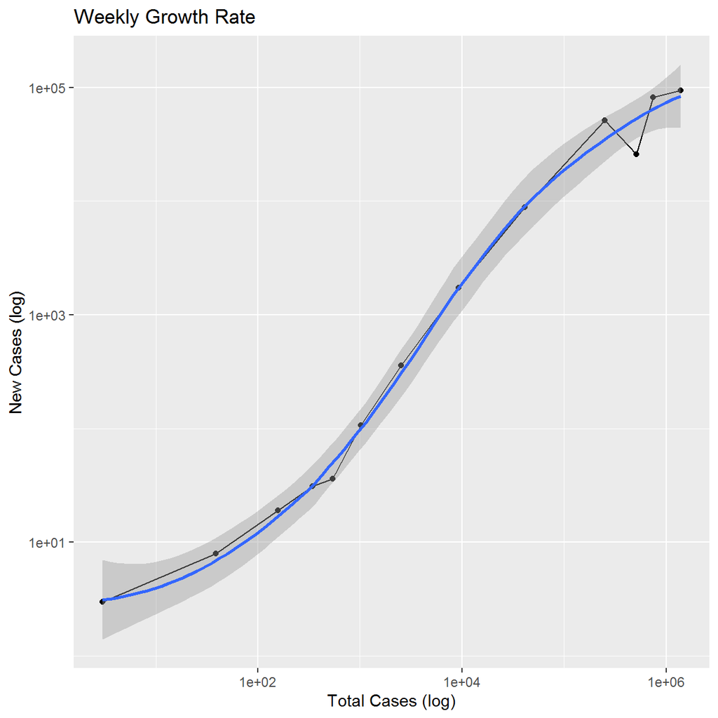

stable weekly growth rate

```r
gr <- cdc %>%
     group_by(`Week Number`) %>%
     summarise(cases = sum(`Number of new cases`),
               cs = sum(cum),
               count = n())

ggplot(data = gr) +
     geom_line(aes(y = `cases`,
                   x = cs)) +
     geom_point(aes(y = `cases`,
                    x = cs)) +
     scale_x_log10() +
     scale_y_log10() +
     geom_smooth(aes(y = `cases`,
                     x = cs)) +
  labs(title = "Weekly Growth Rate",
       x = "Total Cases (log)",
       y = "New Cases (log)")
```